# Bellabeat Case Study - Erick M

**1. Define a Clear Business Task (Ask)**

*Key Stakeholders:*  
- Urska Srsen (CEO - Primary)  
- Sanrido Mur (Executive/C-Suite - Primary)  
- Analytics Team (Secondary)

*Business Task:*  
Analyze smart device usage data to gain insight into how people are already using their smart devices. Using this information, make high-level recommendations for how these trends can inform Bellabeat marketing strategy.

*Main Takeaways from Analysis:*  
- Trends in Smart Devices  
- Actionable insights that can be taken to improve connections to Bellabeat customers  
- Actionable insights that can be implemented to marketing strategy to potentially increase ROI

**2. Description of Data Sources (Prepare)**

- FitBit Dataset

The dataset used in this analysis is available under a public domain license through Kaggle. The dataset contains personal fitness tracker information collected from 33 Fitbit users. Data was collected by a distributed survey via Amazon Mechanical Turk between 04/12/2016-05/12/2016. The data includes users’ active minutes. The dataset contains information on users’ sleep duration. Since the data was generated from a survey of only 33 entries, its sample size is marginal. This data could still be benefit in making inferences of trends.

**3. Data Cleaning and Manipulation (Process)**

*A. Loading Environment*

```r
#Installing Packages for Use in Project: Here I am installing all the packages I would like to use to analyze this data set with the uses going to the cleaning and later analysis process.

install.packages("tidyverse")
install.packages("dplyr")
install.packages("skimr")
install.packages("tidyr")
install.packages("readr")
install.packages("learnr")
```

```r
install.packages("ggplot2")
install.packages("corrgram")
#Here we are loading the library of functions to the console

library(tidyverse)
library(dbplyr)
library(skimr)
library (tidyr)
library(readr)
library(ggplot2)
library(corrgram)
```

*B. Importing Datasets*

```r
#Loading daily datasets - read in data

DailyActivity <- read_csv("/cloud/project/2622327/Fitabase Data 4.12.16-5.12.16/dailyActivity_merged.csv")
DailySleep <- read_csv("/cloud/project/2622327/Fitabase Data 4.12.16-5.12.16/sleepDay_merged.csv")
##Format to drop day from date on HourlySteps table
#This was done in excel with the formula below:
'=text(B2, "hh:mm:ss AM/PM")'
```

```
## [1] "=text(B2, \"hh:mm:ss AM/PM\")"
```

```r
#Then the literal values were copied into the ActivityHour column then the new file was read in by read.csv:

HourlySteps <- read_csv("/cloud/project/2622327/Fitabase Data 4.12.16-5.12.16/hourlySteps_merged - hourlySteps_merged.csv")
```

*C. Exploring Datasets* - For the first part, here we are previewing the datasets

```r
# These functions were repeated for each of the datasets
head(DailyActivity)
```

```
## # A tibble: 6 x 15
##        Id ActivityDate TotalSteps TotalDistance TrackerDistance LoggedActivitie…
##     <dbl> <chr>             <dbl>         <dbl>           <dbl>            <dbl>
## 1  1.50e9 4/12/2016         13162          8.5             8.5                 0
## 2  1.50e9 4/13/2016         10735          6.97            6.97                0
## 3  1.50e9 4/14/2016         10460          6.74            6.74                0
## 4  1.50e9 4/15/2016          9762          6.28            6.28                0
## 5  1.50e9 4/16/2016         12669          8.16            8.16                0
## 6  1.50e9 4/17/2016          9705          6.48            6.48                0
## # … with 9 more variables: VeryActiveDistance <dbl>,
## #   ModeratelyActiveDistance <dbl>, LightActiveDistance <dbl>,
## #   SedentaryActiveDistance <dbl>, VeryActiveMinutes <dbl>,
## #   FairlyActiveMinutes <dbl>, LightlyActiveMinutes <dbl>,
## #   SedentaryMinutes <dbl>, Calories <dbl>
```

```r
colnames(DailyActivity)
```

```
##  [1] "Id"                       "ActivityDate"
##  [3] "TotalSteps"               "TotalDistance"
##  [5] "TrackerDistance"          "LoggedActivitiesDistance"
##  [7] "VeryActiveDistance"       "ModeratelyActiveDistance"
##  [9] "LightActiveDistance"      "SedentaryActiveDistance"
## [11] "VeryActiveMinutes"        "FairlyActiveMinutes"
## [13] "LightlyActiveMinutes"     "SedentaryMinutes"
## [15] "Calories"
```

```r
skim_without_charts(DailyActivity)
```

Data summary

| Name | DailyActivity |
| --- | --- |
| Number of rows | 940 |
| Number of columns | 15 |
| _______________________ |  |
| Column type frequency: |  |
| character | 1 |
| numeric | 14 |
| ________________________ |  |
| Group variables | None |

**Variable type: character**

| skim_variable | n_missing | complete_rate | min | max | empty | n_unique | whitespace |
| --- | --- | --- | --- | --- | --- | --- | --- |
| ActivityDate | 0 | 1 | 8 | 9 | 0 | 31 | 0 |

**Variable type: numeric**

| skim_variable | n_missing | complete_rate | mean | sd | p0 | p25 | p50 | p75 | p100 |
| --- | --- | --- | --- | --- | --- | --- | --- | --- | --- |
| Id | 0 | 1 | 4.855407e+09 | 2.424805e+09 | 1503960366 | 2.320127e+09 | 4.445115e+09 | 6.962181e+09 | 8.877689e+09 |
| TotalSteps | 0 | 1 | 7.637910e+03 | 5.087150e+03 | 0 | 3.789750e+03 | 7.405500e+03 | 1.072700e+04 | 3.601900e+04 |
| TotalDistance | 0 | 1 | 5.490000e+00 | 3.920000e+00 | 0 | 2.620000e+00 | 5.240000e+00 | 7.710000e+00 | 2.803000e+01 |
| TrackerDistance | 0 | 1 | 5.480000e+00 | 3.910000e+00 | 0 | 2.620000e+00 | 5.240000e+00 | 7.710000e+00 | 2.803000e+01 |
| LoggedActivitiesDistance | 0 | 1 | 1.100000e-01 | 6.200000e-01 | 0 | 0.000000e+00 | 0.000000e+00 | 0.000000e+00 | 4.940000e+00 |
| VeryActiveDistance | 0 | 1 | 1.500000e+00 | 2.660000e+00 | 0 | 0.000000e+00 | 2.100000e-01 | 2.050000e+00 | 2.192000e+01 |
| ModeratelyActiveDistance | 0 | 1 | 5.700000e-01 | 8.800000e-01 | 0 | 0.000000e+00 | 2.400000e-01 | 8.000000e-01 | 6.480000e+00 |
| LightActiveDistance | 0 | 1 | 3.340000e+00 | 2.040000e+00 | 0 | 1.950000e+00 | 3.360000e+00 | 4.780000e+00 | 1.071000e+01 |
| SedentaryActiveDistance | 0 | 1 | 0.000000e+00 | 1.000000e-02 | 0 | 0.000000e+00 | 0.000000e+00 | 0.000000e+00 | 1.100000e-01 |
| VeryActiveMinutes | 0 | 1 | 2.116000e+01 | 3.284000e+01 | 0 | 0.000000e+00 | 4.000000e+00 | 3.200000e+01 | 2.100000e+02 |
| FairlyActiveMinutes | 0 | 1 | 1.356000e+01 | 1.999000e+01 | 0 | 0.000000e+00 | 6.000000e+00 | 1.900000e+01 | 1.430000e+02 |
| LightlyActiveMinutes | 0 | 1 | 1.928100e+02 | 1.091700e+02 | 0 | 1.270000e+02 | 1.990000e+02 | 2.640000e+02 | 5.180000e+02 |
| SedentaryMinutes | 0 | 1 | 9.912100e+02 | 3.012700e+02 | 0 | 7.297500e+02 | 1.057500e+03 | 1.229500e+03 | 1.440000e+03 |
| Calories | 0 | 1 | 2.303610e+03 | 7.181700e+02 | 0 | 1.828500e+03 | 2.134000e+03 | 2.793250e+03 | 4.900000e+03 |

```r
head(DailySleep)
```

```
## # A tibble: 6 x 5
##          Id SleepDay           TotalSleepRecor… TotalMinutesAsle… TotalTimeInBed
##       <dbl> <chr>                         <dbl>             <dbl>          <dbl>
## 1    1.50e9 4/12/2016 12:00:0…                1               327            346
## 2    1.50e9 4/13/2016 12:00:0…                2               384            407
## 3    1.50e9 4/15/2016 12:00:0…                1               412            442
## 4    1.50e9 4/16/2016 12:00:0…                2               340            367
## 5    1.50e9 4/17/2016 12:00:0…                1               700            712
## 6    1.50e9 4/19/2016 12:00:0…                1               304            320
```

```r
colnames(DailySleep)
```

```
## [1] "Id"                 "SleepDay"           "TotalSleepRecords"
## [4] "TotalMinutesAsleep" "TotalTimeInBed"
```

```r
skim_without_charts(DailySleep)
```

Data summary

| Name | DailySleep |
| --- | --- |
| Number of rows | 413 |
| Number of columns | 5 |
| _______________________ |  |
| Column type frequency: |  |
| character | 1 |
| numeric | 4 |
| ________________________ |  |
| Group variables | None |

**Variable type: character**

| skim_variable | n_missing | complete_rate | min | max | empty | n_unique | whitespace |
| --- | --- | --- | --- | --- | --- | --- | --- |
| SleepDay | 0 | 1 | 20 | 21 | 0 | 31 | 0 |

**Variable type: numeric**

| skim_variable | n_missing | complete_rate | mean | sd | p0 | p25 | p50 | p75 | p100 |
| --- | --- | --- | --- | --- | --- | --- | --- | --- | --- |
| Id | 0 | 1 | 5.000979e+09 | 2.06036e+09 | 1503960366 | 3977333714 | 4702921684 | 6962181067 | 8792009665 |
| TotalSleepRecords | 0 | 1 | 1.120000e+00 | 3.50000e-01 | 1 | 1 | 1 | 1 | 3 |
| TotalMinutesAsleep | 0 | 1 | 4.194700e+02 | 1.18340e+02 | 58 | 361 | 433 | 490 | 796 |
| TotalTimeInBed | 0 | 1 | 4.586400e+02 | 1.27100e+02 | 61 | 403 | 463 | 526 | 961 |

- Observations:
  1. First I saw that the datasets were split by Daily, Hourly, Minute and Seconds based on the different points that were being tracked like the steps, calories, etc. We will be focusing on the Daily and Hourly to find daily habit and intraday habits of the Fitbit users.
  2. The other daily datasets (Calories, Intensity, Steps) all contained columns that were already in the DailyActivity table so no need for those files to be imported in.
  3. With the DailySleep table, the hour had been included so we are going to drop that part off of the columns observations with the *separate()* function.
  4. Only 24 participants in the Sleep record table and all 33 present in the DailyActivity table. Not using weight log info as there are under 10 people. The only credible sample is from activity metrics so we’ll focus on the Daily datasets
  5. Looking at the final DailyMerged table there are 74 entries (about 7% of data) that has no registered steps but has registered calories and sedentary minutes. With the extra 0’s, it skews the statistical data. We will make a table without the 74 entries during the cleaning.

  *D. Cleaning the Data*
- Format data column ‘ActivityDate’ to uniform date on DailySleep dataframe
- Merge Daily dataframes (Activity and Sleep)
- Make Daily dataframe without “0 step” readings
- Format to drop day from date on HourlySteps table
- Converting minutes to hours
- Making list of all users’ category averages

*Drop time from ‘SleepDay’ column in DailySleep dataframe*

```r
#Using *separate()* to split the observation in the SleepDay column
DailySleep_Edit <- separate(DailySleep, SleepDay, c("Date","Time"), sep = " ", convert = FALSE)
#Delete the newly made column with just the hour
DailySleep_Edit <- subset(DailySleep_Edit, select = -c(Time))

#Check new table for accuracy of execution
head(DailySleep_Edit)
```

```
## # A tibble: 6 x 5
##           Id Date      TotalSleepRecords TotalMinutesAsleep TotalTimeInBed
##        <dbl> <chr>                 <dbl>              <dbl>          <dbl>
## 1 1503960366 4/12/2016                 1                327            346
## 2 1503960366 4/13/2016                 2                384            407
## 3 1503960366 4/15/2016                 1                412            442
## 4 1503960366 4/16/2016                 2                340            367
## 5 1503960366 4/17/2016                 1                700            712
## 6 1503960366 4/19/2016                 1                304            320
```

*Merge DailyActivity and new DailySleep table into cohesive dataframe*

```r
DailyMerged <- left_join(DailyActivity, DailySleep_Edit, by = c('Id' = 'Id','ActivityDate' = 'Date'))
```

*Remove “0 step” readings from dataset*

```r
DailyMergedEdit <- filter(DailyMerged, TotalSteps != 0)

head(DailyMergedEdit)
```

```
## # A tibble: 6 x 18
##        Id ActivityDate TotalSteps TotalDistance TrackerDistance LoggedActivitie…
##     <dbl> <chr>             <dbl>         <dbl>           <dbl>            <dbl>
## 1  1.50e9 4/12/2016         13162          8.5             8.5                 0
## 2  1.50e9 4/13/2016         10735          6.97            6.97                0
## 3  1.50e9 4/14/2016         10460          6.74            6.74                0
## 4  1.50e9 4/15/2016          9762          6.28            6.28                0
## 5  1.50e9 4/16/2016         12669          8.16            8.16                0
## 6  1.50e9 4/17/2016          9705          6.48            6.48                0
## # … with 12 more variables: VeryActiveDistance <dbl>,
## #   ModeratelyActiveDistance <dbl>, LightActiveDistance <dbl>,
## #   SedentaryActiveDistance <dbl>, VeryActiveMinutes <dbl>,
## #   FairlyActiveMinutes <dbl>, LightlyActiveMinutes <dbl>,
## #   SedentaryMinutes <dbl>, Calories <dbl>, TotalSleepRecords <dbl>,
## #   TotalMinutesAsleep <dbl>, TotalTimeInBed <dbl>
```

*Adding columns converting minutes to hours for activity data*

```r
DailyMerged <- mutate(DailyMerged, VeryActiveHours = DailyMerged$VeryActiveMinutes/60, FairlyActiveHours = DailyMerged$FairlyActiveMinutes/60, LightlyActiveHours = DailyMerged$LightlyActiveMinutes/60, SedentaryHours = DailyMerged$SedentaryMinutes/60)

head(DailyMerged)
```

```
## # A tibble: 6 x 22
##        Id ActivityDate TotalSteps TotalDistance TrackerDistance LoggedActivitie…
##     <dbl> <chr>             <dbl>         <dbl>           <dbl>            <dbl>
## 1  1.50e9 4/12/2016         13162          8.5             8.5                 0
## 2  1.50e9 4/13/2016         10735          6.97            6.97                0
## 3  1.50e9 4/14/2016         10460          6.74            6.74                0
## 4  1.50e9 4/15/2016          9762          6.28            6.28                0
## 5  1.50e9 4/16/2016         12669          8.16            8.16                0
## 6  1.50e9 4/17/2016          9705          6.48            6.48                0
## # … with 16 more variables: VeryActiveDistance <dbl>,
## #   ModeratelyActiveDistance <dbl>, LightActiveDistance <dbl>,
## #   SedentaryActiveDistance <dbl>, VeryActiveMinutes <dbl>,
## #   FairlyActiveMinutes <dbl>, LightlyActiveMinutes <dbl>,
## #   SedentaryMinutes <dbl>, Calories <dbl>, TotalSleepRecords <dbl>,
## #   TotalMinutesAsleep <dbl>, TotalTimeInBed <dbl>, VeryActiveHours <dbl>,
## #   FairlyActiveHours <dbl>, LightlyActiveHours <dbl>, SedentaryHours <dbl>
```

**Make a list of every users’ category averages**

```r
DailyMergedList1 <- aggregate(list(AvgSteps = DailyMergedEdit$TotalSteps, AvgDistance = DailyMergedEdit$TotalDistance, ModerateDistance = DailyMergedEdit$ModeratelyActiveDistance, ActiveDistance = DailyMergedEdit$VeryActiveDistance, LightDistance = DailyMergedEdit$LightActiveDistance, ModerateMinutes = DailyMergedEdit$FairlyActiveMinutes/60, ActiveMinutes = DailyMergedEdit$VeryActiveMinutes/60, LightMinutes = DailyMergedEdit$LightlyActiveMinutes/60, SittingMinutes = DailyMergedEdit$SedentaryMinutes/60, AvgCalories = DailyMergedEdit$Calories), by = list(Id = DailyMergedEdit$Id), mean)

head(DailyMergedList1)
```

```
##           Id  AvgSteps AvgDistance ModerateDistance ActiveDistance
## 1 1503960366 12520.633    8.070000       0.82066666     2.95366668
## 2 1624580081  5743.903    3.914839       0.36064516     0.93935484
## 3 1644430081  7282.967    5.295333       0.95100000     0.73000000
## 4 1844505072  3808.667    2.518571       0.07238095     0.01238095
## 5 1927972279  1670.588    1.157059       0.05705882     0.17470588
## 6 2022484408 11370.645    8.084193       0.72000000     2.42161288
##   LightDistance ModerateMinutes ActiveMinutes LightMinutes SittingMinutes
## 1     4.2913333      0.33000000   0.666666667     3.787778       13.80722
## 2     2.6067742      0.09677419   0.144623656     2.558065       20.96237
## 3     3.6090000      0.35611111   0.159444444     2.974444       19.36444
## 4     2.4319047      0.03174603   0.003174603     2.840476       18.83651
## 5     0.9247059      0.02352941   0.040196078     1.172549       20.73922
## 6     4.9425806      0.32258065   0.604838710     4.290860       18.54301
##   AvgCalories
## 1    1876.967
## 2    1483.355
## 3    2811.300
## 4    1713.762
## 5    2303.059
## 6    2509.968
```

- After creating the new comprehensive DailyMerged table, there were NA values (24 participants with sleep data vs 33 of total participants) so we will ignore those during statistical analysis.

**4. Data Analysis and Findings (Analyze & Share)**

- Now lets look at a summary of the data and see what we can find:

```r
DailyMergedEdit %>% summary()
```

```
##        Id            ActivityDate         TotalSteps    TotalDistance
##  Min.   :1.504e+09   Length:866         Min.   :    4   Min.   : 0.000
##  1st Qu.:2.320e+09   Class :character   1st Qu.: 4927   1st Qu.: 3.373
##  Median :4.445e+09   Mode  :character   Median : 8056   Median : 5.595
##  Mean   :4.861e+09                      Mean   : 8333   Mean   : 5.992
##  3rd Qu.:6.962e+09                      3rd Qu.:11101   3rd Qu.: 7.918
##  Max.   :8.878e+09                      Max.   :36019   Max.   :28.030
##
##  TrackerDistance  LoggedActivitiesDistance VeryActiveDistance
##  Min.   : 0.000   Min.   :0.0000           Min.   : 0.000
##  1st Qu.: 3.373   1st Qu.:0.0000           1st Qu.: 0.000
##  Median : 5.595   Median :0.0000           Median : 0.410
##  Mean   : 5.977   Mean   :0.1198           Mean   : 1.638
##  3rd Qu.: 7.888   3rd Qu.:0.0000           3rd Qu.: 2.277
##  Max.   :28.030   Max.   :4.9421           Max.   :21.920
##
##  ModeratelyActiveDistance LightActiveDistance SedentaryActiveDistance
##  Min.   :0.0000           Min.   : 0.000      Min.   :0.000000
##  1st Qu.:0.0000           1st Qu.: 2.350      1st Qu.:0.000000
##  Median :0.3100           Median : 3.580      Median :0.000000
##  Mean   :0.6216           Mean   : 3.647      Mean   :0.001744
##  3rd Qu.:0.8700           3rd Qu.: 4.900      3rd Qu.:0.000000
##  Max.   :6.4800           Max.   :10.710      Max.   :0.110000
##
##  VeryActiveMinutes FairlyActiveMinutes LightlyActiveMinutes SedentaryMinutes
##  Min.   :  0.00    Min.   :  0.00      Min.   :  0.0        Min.   :   0.0
##  1st Qu.:  0.00    1st Qu.:  0.00      1st Qu.:146.2        1st Qu.: 721.0
##  Median :  7.00    Median :  8.00      Median :208.0        Median :1020.0
##  Mean   : 23.09    Mean   : 14.84      Mean   :210.2        Mean   : 954.9
##  3rd Qu.: 35.00    3rd Qu.: 21.00      3rd Qu.:272.0        3rd Qu.:1189.0
##  Max.   :210.00    Max.   :143.00      Max.   :518.0        Max.   :1440.0
##
##     Calories    TotalSleepRecords TotalMinutesAsleep TotalTimeInBed
##  Min.   :  52   Min.   :1.000     Min.   : 58.0      Min.   : 61.0
##  1st Qu.:1857   1st Qu.:1.000     1st Qu.:361.0      1st Qu.:403.0
##  Median :2222   Median :1.000     Median :433.0      Median :463.0
##  Mean   :2365   Mean   :1.119     Mean   :419.5      Mean   :458.6
##  3rd Qu.:2838   3rd Qu.:1.000     3rd Qu.:490.0      3rd Qu.:526.0
##  Max.   :4900   Max.   :3.000     Max.   :796.0      Max.   :961.0
##                 NA's   :453       NA's   :453        NA's   :453
```

[output not shown]

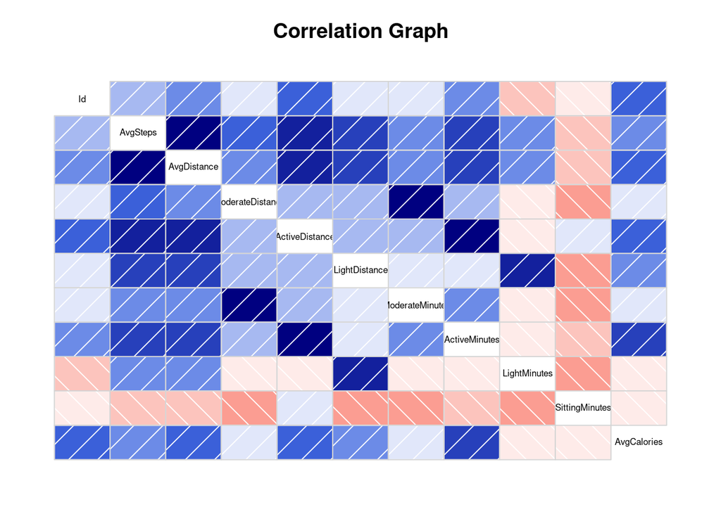

```r
corrgram(DailyMergedList1, order = NULL, panel=panel.shade, text.panel=panel.txt, main="Correlation Graph")
```

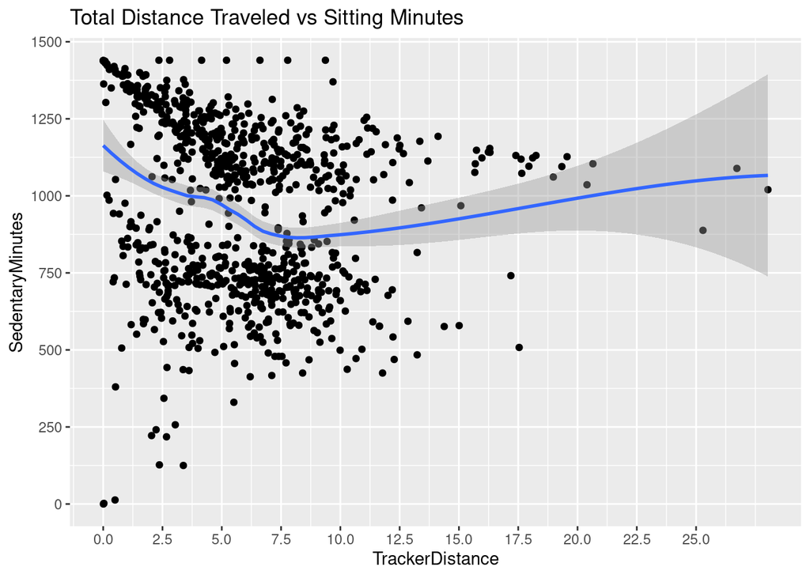

```r
#Tracker Distance vs Sedentary Minutes
ggplot(data = DailyMergedEdit, aes(x = TrackerDistance , y = SedentaryMinutes)) + geom_point() + geom_smooth() + scale_x_continuous(breaks=seq(0, 25, by = 2.5)) + scale_y_continuous(breaks=seq(0, 1500, by = 250)) + labs(title = "Total Distance Traveled vs Sitting Minutes")
```

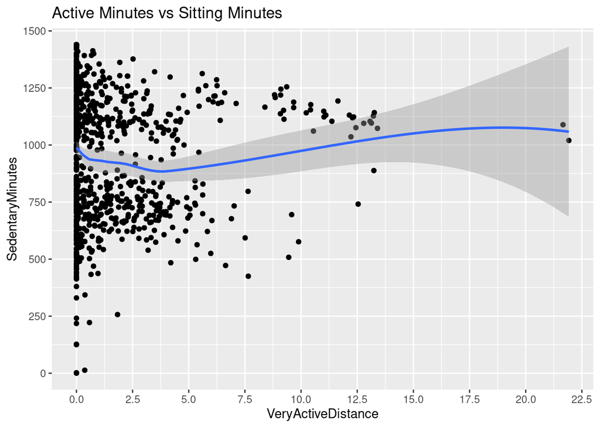

```r
#VeryActiveMinutes vs SedentaryMinutes
ggplot(data = DailyMergedEdit, aes(x = VeryActiveDistance , y = SedentaryMinutes)) + geom_point() + geom_smooth() + scale_x_continuous(breaks=seq(0, 25, by = 2.5)) + scale_y_continuous(breaks=seq(0, 1500, by = 250)) + labs(title = "Active Minutes vs Sitting Minutes")
```

- For a majority of the data, the scatter plots show a slight negative correlation between distance and sitting.

*Sitting Minutes vs Calories Burned*

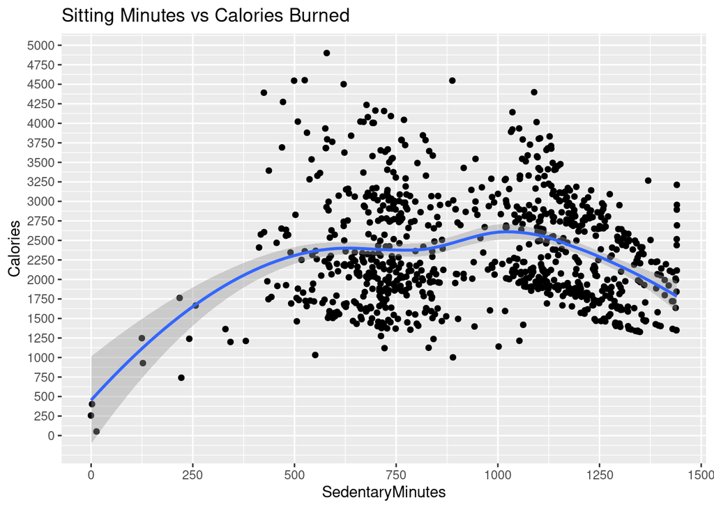

```r
#Sitting Minutes vs Calories
ggplot(data = DailyMergedEdit, aes(x = SedentaryMinutes, y = Calories)) + geom_jitter() + geom_smooth() + scale_x_continuous(breaks=seq(0,1500, by = 250)) + scale_y_continuous(breaks=seq(0, 5000, by = 250)) + labs(title = "Sitting Minutes vs Calories Burned")
```

*Do people who sleep more burn less calories?*

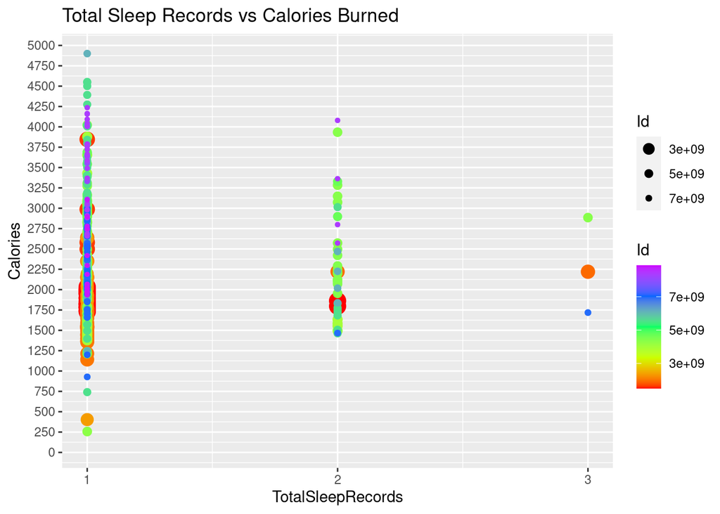

```r
#TotalSleepRecords vs Calories Burned
ggplot(data = DailyMergedEdit, aes(x = TotalSleepRecords, y = Calories, color = Id, size = Id)) + geom_point() + scale_x_continuous(breaks = seq(0,3,by=1)) + scale_y_continuous(breaks = seq(0,5000, by = 250)) +  scale_color_gradientn(colours = rainbow(5)) +
  scale_size_continuous(range = c(5,1)) + labs(title = "Total Sleep Records vs Calories Burned")
```

- I wanted to see if one part of the dataset accounted for more of the calories burned than they rest of the participants. This was signified by the color and sizes of the dots. The lower on the scale, the lower numeric Id value of the participant. Likewise with the point size, the bigger the point the lower numeric Id of the participant.

[output not shown]

*Total Steps by Hour of Day*

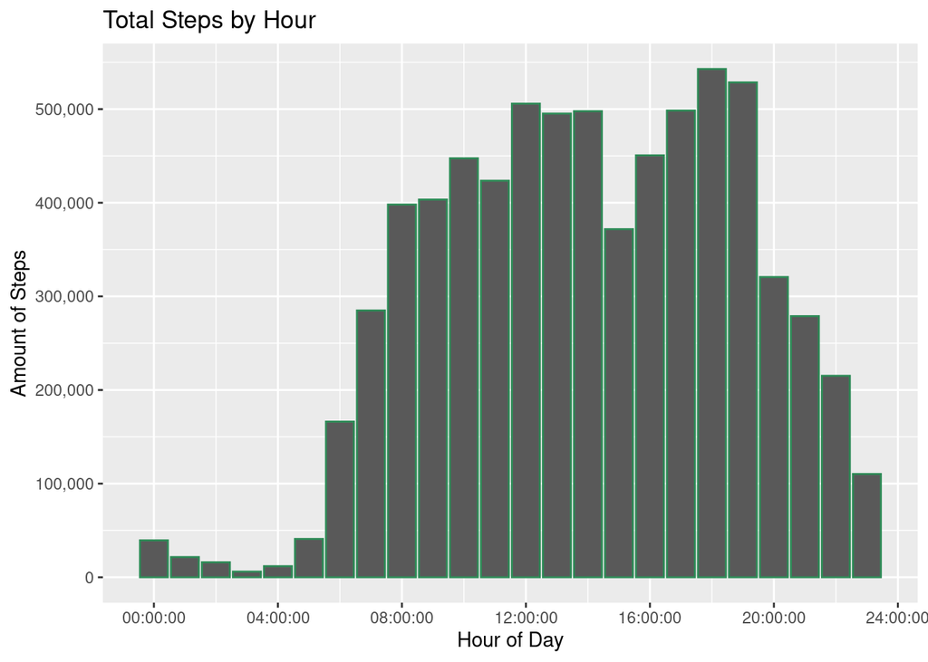

```r
#Total Steps by Hour of Day
StepsbyHour <- aggregate(cbind(StepTotal) ~ ActivityHour , data = HourlySteps , FUN = sum )

ggplot(data = StepsbyHour, aes(x=ActivityHour, weight=StepTotal)) + geom_bar(color = "seagreen") + scale_y_continuous(breaks = seq(0, 600000, by = 100000), labels = scales::comma) + labs(title = "Total Steps by Hour", x = "Hour of Day", y = "Amount of Steps")
```

- The most active times of the day are between 5p-7p with the next busiest times being between 12p-2p.

  ```
        Thank you for your time.
  ```